# Prediction, Bootstrapping and Monte Carlo Analyses Based on Linear Mixed Models with QAPE 2.0 Package

Alicja Wolny–Dominiak

Department of Statistical and Mathematical Methods in Economics

Tomasz Ża̧dło

Department of Statistics, Econometrics and Mathematics

2025-01-10

Abstract

The paper presents a new R package [**qape**](https://CRAN.R-project.org/package=qape) for prediction, accuracy estimation of various predictors and Monte Carlo simulation studies of properties of both predictors and estimators of accuracy measures. It allows to predict any population and subpopulation characteristics of the response variable based on the Linear Mixed Model (LMM). The response variable can be transformed, e.g. to logarithm and the data can be in the cross-sectional or longitudinal framework. Three bootstrap algorithms are developed: parametric, residual and double, allowing to estimate the prediction accuracy. Analyses can also include Monte Carlo simulation studies of properties of the methods used. Unlike other packages, in the prediction process the user can flexibly define the predictor, the model, the transformation function of the response variable, the predicted characteristics and the method of accuracy estimation.

## Introduction

One of the tasks in application of mixed models in the real-life problems is the prediction of random effects. Then, the predicted values give the possibility for further prediction, e.g. characteristics of interest such as sum, mean or quantiles or the future value of the response variable for cross-sectional or longitudinal data.

Three main predictors of these characteristics are proposed in the literature: Empirical Best Linear Unbiased Predictors - EBLUPs (see e.g. (Henderson 1950) and (Royall 1976)), PLUG-IN predictors (see e.g. (Boubeta, Lombardı́a, and Morales 2016), (Chwila and Żądło 2019), (Hobza and Morales 2016)) and Empirical Best Predictors - EBPs (see e.g. (Molina and Rao 2010)). Each assumes the LMM to model the response variable.

The numerous successful applications of these three predictors for cross-sectional and longitudinal data can be found in the model approach in survey sampling, including the small area estimation. In paper (Fay III and Herriot 1979) the Authors introduce the prediction of the mean income for small places based on the special case of the LMM model called Fay-Herriot model and the EBLUP. The analysis of poverty is extended in many works, e.g. in (Molina and Rao 2010) and (Christiaensen et al. 2012). In turn, in (Battese, Harter, and Fuller 1988) the Authors analyse the total crop areas based on survey and satellite data using EBLUPs. The proposed LMM model is known as the Battese-Harter-Fuller model. The predictors are also exploited in the subject of experience rating in non-life insurance, see (Frees, Young, and Luo 1999) and (Bühlmann and Gisler 2005), where the longitudinal data are under consideration. The insurance premium for the next period for every policy in the insurance portfolio is predicted.

A major challenge in this type of prediction is the estimation of the prediction accuracy measure. Most often it is the Root Mean Squared Error (RMSE), which is given in analytical form or can be e.g. estimated using bootstrap. A feature of the distribution of the squared prediction error is usually a very strong positive asymmetry. Because the mean is not recommended as the appropriate measure of the central tendency in such distributions, the alternative prediction accuracy measure called the Quantile of Absolute Prediction Errors (QAPE), proposed by (T. Żądło 2013) and (Wolny-Dominiak and Żądło 2020), can be applied.

There is a variety of R packages to calculate the considered predictors together with the accuracy measure of prediction, usually the RMSE. The package [**sae**](https://CRAN.R-project.org/package=sae), see (Molina and Marhuenda 2015), provides EBLUPs based on Fay-Herriot and Battese-Harter-Fuller models. In turn, the multivariate EBLUP for Fay-Herriot models is implemented in [**msae**](https://CRAN.R-project.org/package=msae), see (Permatasari and Ubaidillah 2021). Several EBLUPs introduced in (Jon NK Rao and Yu 1994) are implemented in package [**saery**](https://CRAN.R-project.org/package=saery) introduced by (Lefler, Gonzalez, and Martin 2014), likewise in [**JoSAE**](https://CRAN.R-project.org/package=JoSAE), see (Breidenbach 2018), but with additional heteroscedasticity analysis. The EBP is provided in the package [**emdi**](https://CRAN.R-project.org/package=emdi) described in (Kreutzmann et al. 2019).

A new package in this area is our proposed package [**qape**](https://CRAN.R-project.org/package=qape). It allows the prediction of flexibly defined characteristics of the response variable using the above three predictors, assuming an appropriate LMM. A novel feature of the package [**qape**](https://CRAN.R-project.org/package=qape), compared to those already in place, is the ability of bootstrap estimation of the prediction accuracy measures, both the RMSE and QAPE. Three types of bootstrap procedures are provided: parametric, residual and double.

There are three groups of functions in this package: predictors values calculation, bootstrap estimation of RMSE and QAPE measures, and Monte Carlo (MC) analysis of properties of predictors and prediction accuracy estimators. The prediction is based on a LMM model defined by the user and allows to predict the population characteristics of the response variable, which can be defined by a linear combination (in the case of EBLUP), by any R function (e.g. `sum`) or any function defined by the user (in the case of the EBP and PLUG-IN predictors). The package allows for full flexibility in defining: the model, the predicted characteristic, and the transformation of the response variable.

This paper is organized as follows. Firstly, the background of the LMM is presented together with the theoretical foundations of the prediction including prediction accuracy measures. Then, the package functionality in the area of prediction is presented and illustrated. A short application based on `radon` data, a cross-sectional dataset available in [**HLMdiag**](https://CRAN.R-project.org/package=HLMdiag) package, to predict three subpopulation characteristics is shown. Subsequently, the theoretical background of the prediction accuracy measures estimation based on bootstrap is presented. Implementations of bootstrap algorithms in [**qape**](https://CRAN.R-project.org/package=qape) are briefly introduced. Finally, the procedure of the model-based Monte Carlo simulation study is discussed. The paper ends with a conclusion.

## Prediction accuracy measures

We consider the problem of prediction of any given function of the population vector $\mathbf{Y}$ of the response variable:
$$\label{theta}
\theta = f_{\theta}(\mathbf{Y}) (\#eq:theta)$$
under the LMM. It covers linear combinations of $\mathbf{Y}$ (such as one future realization of the response variable or population and subpopulation means and totals) but also other population and subpopulation characteristics such quantiles and variability measures.

To assess the accuracy of the particular predictor $\hat \theta$, firstly, the prediction error is defined as $U=\hat{\theta}-\theta$. Therefore, the well-known RMSE has the following formula:
$$\label{eq0}
RMSE(\hat{\theta})=\sqrt{E(\hat{\theta}-\theta)^{2}}=\sqrt{E({{U}^{2}})}. (\#eq:eq0)$$
The alternative to the RMSE based on the mean could be the QAPE based on quantiles. It represents the $p$th quantile of the absolute prediction error $|U|$, see (T. Żądło 2013) and (Wolny-Dominiak and Żądło 2020), and it is given by:
$$\label{eq1}
QAPE_p(\hat{\theta}) = \inf \left\{ {x:P\left( {\left|
{{\hat{\theta}-\theta}} \right| \le x} \right) \ge p} \right\} =\inf
\left\{ {x:P\left( {\left| {{U}} \right| \le x} \right) \ge p}
\right\} (\#eq:eq1)$$
This measure informs that at least $p100\%$ of observed absolute prediction errors are smaller than or equal to $QAPE_p(\hat{\theta})$, while at least $(1-p)100\%$ of them are higher than or equal to $QAPE_p(\hat{\theta})$. Quantiles reflect the relation between the magnitude of the error and the probability of its realization. It means that using the QAPE, it is possible to make a full description of the distribution of prediction errors instead of using the average (reflected by the RMSE). Furthermore, the MSE is the mean of positively (usually very strongly) skewed squared prediction errors, where the mean should not be used as a measure of the central tendency of positively skewed distributions.

The above described accuracy prediction measures RMSE and QAPE can be estimated using the bootstrap techniques. Their estimators as well as the bootstrap distributions of the prediction errors based on any (assumed or misspecified) model are provided in [**qape**](https://CRAN.R-project.org/package=qape) package, including algorithms where the parallel computing is used.

In the [**qape**](https://CRAN.R-project.org/package=qape) package, the whole prediction process has its own specific procedure, which can be presented in the following steps.

**Procedure 1**. *The process of prediction, accuracy measures estimation and Monte Carlo simulation analyses in [**qape**](https://CRAN.R-project.org/package=qape)*

1. *Define the characteristics of the response variable to predict,*
2. *provide the information on sample and population values,*
3. *define the LMM,*
4. *estimate parameters of the LMM,*
5. *predict the random variable $\theta$ using the chosen class of predictors,*
6. *estimate the prediction accuracy measures RMSE and QAPE using one of the developed bootstrap algorithms,*
7. *conduct simulation analyses of properties of predictors and accuracy measures estimators under any (also misspecified) LMM model.*

## The prediction under LMM

The main functions of the [**qape**](https://CRAN.R-project.org/package=qape) package provide the bootstrap estimation of prediction accuracy measures. However, it must be preceded by the prediction process, including the choice of the LMM and the predictor.

### The model

Let $\mathbf{Y}$ denote the vector of response variables $Y_1, Y_2,..., Y_N$. Assuming, without a loss of generality, that only the first $n$ realizations of $Y_i$ are observed, $\mathbf{Y}$ can be decomposed as $\mathbf{Y}= \begin{bmatrix} \mathbf{Y}_s^T & \mathbf{Y}_r^T \end{bmatrix}^T$ , where $\mathbf{Y}_s$ and $\mathbf{Y}_r$ are of dimension $n \times 1$ and $(N - n) \times 1$, respectively. In all notations, the subscript "s" is used for observed realizations of the variable of interest and "r" for the unobserved ones. Two known matrices of auxiliary variables are also considered, denoted by $\mathbf{X}$ and $\mathbf{Z}$, which are associated with fixed and random effects, respectively. The $\mathbf{X}$ matrix is of dimension $N \times p$, and it consists of $p$ regression variables. It can be decomposed like $\mathbf{Y}$ as follows: $\mathbf{X}= \begin{bmatrix} \mathbf{X}_s^T & \mathbf{X}_r^T \end{bmatrix}^T$, where matrices $\mathbf{X}_s$ and $\mathbf{X}_r$, both known, are of dimension $n \times p$ and $(N-n) \times p$, respectively. Similarly, the $\mathbf{Z}$ matrix of dimension $N \times h$ can be written as follows: $\mathbf{Z}= \begin{bmatrix} \mathbf{Z}_s^T & \mathbf{Z}_r^T \end{bmatrix}^T$, where matrices $\mathbf{Z}_s$ and $\mathbf{Z}_r$, both known, are of dimension $n \times h$ and $(N-n) \times h$, respectively.

Then, let $LMM(\mathbf{X}, \mathbf{Z}, \boldsymbol{\psi})$ denotes the LMM of the following form (e.g. (John NK Rao and Molina 2015), p. 98):
$$\label{LMM}
\left\{ \begin{array}{c}
\mathbf{Y}=\mathbf{X}\boldsymbol{\beta} +
\mathbf{Z}\mathbf{v}+\mathbf{e} \\
E(\mathbf{e})=\mathbf{0}, E(\mathbf{v})=\mathbf{0} \\
Var(\mathbf{e})=\mathbf{R}(\pmb{\delta}),
Var(\mathbf{v})=\mathbf{G}(\pmb{\delta})
\end{array} \right. (\#eq:LMM)$$
The vector of parameters in model (@ref(eq:LMM)) is then $\boldsymbol{\psi}=\begin{bmatrix} \boldsymbol{\beta}^T & \pmb{\delta}^T \end{bmatrix}^T$, where $\boldsymbol{\beta}$ is a vector of fixed effects of dimension $p \times 1$ and $\pmb{\delta}$ is a vector of variance components. The random part of the model is described by the known matrix $\mathbf{Z}$, a vector $\mathbf{v}$ of random effects of dimension $h \times 1$ and a vector $\mathbf{e}$ of random components of dimension $N\times 1$, where $\mathbf{e}$ and $\mathbf{v}$ are assumed to be independent. The vector of random components $\mathbf{e}$ will be decomposed similarly to the vector $\mathbf{Y}$, i.e. $\mathbf{e}=\begin{bmatrix} \mathbf{e}_s^T & \mathbf{e}_r^T \end{bmatrix}^T$.

In the residual bootstrap implemented in [**qape**](https://CRAN.R-project.org/package=qape), there is a need to re-write the LMM model to take account of the specific structure of data, i.e. the grouping variables taken into account in the random part of the model. In this case, without a loss of the generality, the LMM model can be written as follows:
$$\label{LMMa}
\mathbf{Y}=\mathbf{X}\boldsymbol{\beta} +
\mathbf{Z}_1\mathbf{v}_1+...+\mathbf{Z}_l\mathbf{v}_l+...+\mathbf{Z}_L\mathbf{v}_L+\mathbf{e}, (\#eq:LMMa)$$
where $\mathbf{v}_1,\dots,\mathbf{v}_l,\dots,\mathbf{v}_L$ are independent vectors of random effects assumed for different divisions of the $\mathbf{Y}$ vector (under different grouping of the data) and $\mathbf{Z}_1, \dots, \mathbf{Z}_l, \dots, \mathbf{Z}_L$ are known matrices of auxiliary variables associated with random effects. Writing in (@ref(eq:LMMa)): $\mathbf{Z}= \begin{bmatrix} \mathbf{Z}_1 & \dots & \mathbf{0} & \dots & \mathbf{0} \\ \vdots & \ddots & & & \vdots \\ \mathbf{0} & \dots & \mathbf{Z}_l & \dots & \mathbf{0} \\ \vdots & & & \ddots & \vdots \\ \mathbf{0} & \dots & \mathbf{0} & \dots & \mathbf{Z}_L \\ \end{bmatrix}$ and $\mathbf{v}= \begin{bmatrix} \mathbf{v}_1^T & \dots & \mathbf{v}_l^T & \dots & \mathbf{v}_L^T \\ \end{bmatrix}^T$ the LMM model is obtained. Let

$$\label{vl}
\mathbf{v}_l=\left[ \mathbf{v}_{l1}^T \dots \mathbf{v}_{lk}^T \dots
\mathbf{v}_{lK_l}^T \right]^T (\#eq:vl)$$
be of dimension $K_l J_l \times 1$, where $\mathbf{v}_{lk}$ is of dimension $J_l \times 1$ for all $k=1,...,K_l$ and $K_l$ is the number of random effects at the $l$th level of grouping. Hence, $\mathbf{Z}_l$ is $N \times K_l J_l$. For example, if the random regression coefficient model is considered with two random coefficients where both random effects are subpopulation-specific, where $D$ is the number of subpopulations, then $L=1$, $K_1=2$ and $J_1=D$.

### Predictors

In the [**qape**](https://CRAN.R-project.org/package=qape) package, in the general case the predicted characteristic is given by any function of response variables:
$$\label{ftheta}
\theta = f_{\theta}(\mathbf{Y}). (\#eq:ftheta)$$
Under the $LMM(\mathbf{X}, \mathbf{Z}, \boldsymbol{\psi})$ model it could be predicted using one of three predictors:

1. Empirical Best Linear Unbiased Predictor (EBLUP),
2. Empirical Best Predictor (EBP) under nested error LMM,
3. PLUG-IN predictor under the LMM.

The first predictor (EBLUP) allows to predict the linear combination of the response variables:
$$\label{l.theta}
\theta = f_{\theta}(\mathbf{Y}) = \boldsymbol{\gamma}^T \mathbf{Y}=
\boldsymbol{\gamma}_s^T \mathbf{Y}_s + \boldsymbol{\gamma}_r^T
\mathbf{Y}_r, (\#eq:l-theta)$$
where $\boldsymbol{\gamma}$ is a vector of weights. In this case, the predicted characteristic $\theta$ is basically the linear combination of the response variable. For example, if one of the elements of $\boldsymbol{\gamma}$ equals 1 and the rest of the elements equals 0, then one realization of the response variable is predicted. If all elements in $\boldsymbol{\gamma}$ vector equal 1, then $\theta$ becomes the sum of all $Y_i$’s in the whole considered population dataset. The two-stage EBLUP corresponds to the Best Linear Unbiased Predictor (BLUP) introduced in (Henderson 1950) and (Royall 1976) as:
$$\label{BLUP}
\hat{\theta}^{BLUP} (\pmb{\delta}) = {\boldsymbol{\gamma}}_s^T
\mathbf{Y}_s + \hat{\theta}_r(\pmb{\delta}), (\#eq:BLUP)$$
where the predictor of the linear combination $\boldsymbol{\gamma}_r^T \mathbf{Y}_r$ of unobserved random variables is given by $\hat{\theta}_r(\pmb{\delta})={\boldsymbol{\gamma }}_r^T {{\mathbf{X}}_r}{\tilde{\boldsymbol{\beta}} }(\pmb{\delta}) +\boldsymbol{\gamma }_r^T{\mathbf{Z}}_r{\mathbf{\tilde{v}}}(\pmb{\delta})$, where $\tilde{\boldsymbol{\beta}}(\pmb{\delta})$ is the Best Linear Unbiased Estimator of $\boldsymbol{\beta}$ and $\tilde{\mathbf{v}}(\pmb{\delta})$ is the Best Linear Unbiased Predictor of $\mathbf{v}$, both presented in (@ref(eq:LMM)). As shown by (Tomasz Żądło 2017) p. 8094, if $Cov(\mathbf{e}_r, \mathbf{e}_s)=\mathbf{0}$, then the predictor (@ref(eq:BLUP)) is the BLUP of $\theta$ defined as the linear combination (@ref(eq:l-theta)). Even if $Cov(\mathbf{e}_r, \mathbf{e}_s) \neq \mathbf{0}$, the predictor $\hat{\theta}_r(\pmb{\delta})$ is the Best Linear Unbiased Predictor of the following linear combination of $\boldsymbol{\beta}$ and $\mathbf{v}$: ${\boldsymbol{\gamma }}_r^T{{\mathbf{X}}_r}{ {\boldsymbol{\beta}} } +\boldsymbol{\gamma }_r^T{\mathbf{Z}}_r{\mathbf{{v}}}$. The EBLUP $\hat\theta^{EBLUP}$ is obtained by replacing the vector of variance components $\pmb{\delta}$ in BLUP (@ref(eq:BLUP)) with the estimator $\hat{\pmb{\delta}}$. If (a) the expectation of the predictor is finite, (b) $\hat{\pmb{\delta}}$ is any even, translation-invariant estimator of $\pmb{\delta}$, (c) the distributions of both random effects and random components are symmetric around $\mathbf{0}$ (not necessarily normal), the EBLUP remains unbiased, as proved by (Kackar and Harville 1981).

To introduce the second predictor, called EBP, considered e.g. by (Molina and Rao 2010), firstly, the Best Predictor (BP) $\hat{\theta}^{BP}$ of characteristic $\theta(\mathbf{Y})$ has to be defined. It is computed by minimizing the Mean Squared Error $MSE(\hat\theta )=E(\hat\theta - \theta)^2$ and can be written as $\hat\theta^{BP} = E(\theta|\mathbf{Y}_s)$. It means that the conditional distribution of $\mathbf{Y}_r|\mathbf{Y}_s$ must be known to compute its value while at least the parameters of this distribution, denoted by $\boldsymbol{\psi}$ in (@ref(eq:LMM)), are unknown. The EBP $\hat\theta^{EBP}$ is obtained by replacing these parameters with estimators $\hat{\boldsymbol{\psi}}$. Its value can be computed according to the Monte Carlo procedure presented in the supplementary document for this paper.

The last predictor is the PLUG-IN predictor defined as (e.g. (Chwila and Żądło 2019)):
$$\hat{\theta}^{PLUG-IN}=\theta(\begin{bmatrix}
\mathbf{Y}_s^T & \mathbf{\hat{Y}}_r^T
\end{bmatrix}^T),$$
where $\mathbf{\hat{Y}}_r$ is the vector of fitted values of unobserved random variables under the assumed model (any model specified by the statistician). Under the LMM and if the linear combination of $\mathbf{Y}$ is predicted, the PLUG-IN predictor is the EBLUP, but generally, it is not optimal. However, it was shown in simulation studies that it can have similar or even higher accuracy compared to empirical (estimated) best predictors, where the best predictors minimize the prediction mean squared errors (cf. e.g. (Boubeta, Lombardı́a, and Morales 2016), (Chwila and Żądło 2019), (Hobza and Morales 2016)). Moreover, the PLUG-IN predictor is less computationally demanding than the EBP.

### Predictors in [**qape**](https://CRAN.R-project.org/package=qape)

To deal with the LMM model, the [**qape**](https://CRAN.R-project.org/package=qape) package uses the `lmer()` function from the [**lme4**](https://CRAN.R-project.org/package=lme4) package, see (Bates et al. 2015). Assuming (@ref(eq:LMM)) and based on $\mathbf{Y}_s$, the vector of model parameters $\boldsymbol{\psi} = [\boldsymbol{\beta}^T, \pmb{\delta}^T]^T$ is estimated using the Restricted Maximum Likelihood Method (REML), known to be robust on non-normality, see e.g (Jiang 1996), and $\hat{\boldsymbol{\psi}}$ is obtained.

In order to obtain the predictor of $\theta$, one of the three [**qape**](https://CRAN.R-project.org/package=qape) functions can be applied: `EBLUP()`, `ebpLMMne()` or `plugInLMM()`. Firstly, the characteristic of response variables of interest has to be defined. It is actually obvious for EBLUP, which can be used only to predict the population/subpopulation linear combination (e.g. the sum) by using the argument `gamma` equivalent to the population vector of weights $\boldsymbol{\gamma}$ in (@ref(eq:l-theta)). For other two predictors, the EBP and the PLUG-IN, the input argument called `thetaFun` has to be given (see $f_{\theta}(.)$ in (@ref(eq:ftheta))). Function `thetaFun` could define one characteristic or a vector of characteristics, for example:

```r
> thetaFun1 <- function(x) median(x)
> thetaFun2 <- function(x) c(sum(x), mean(x), sd(x))
```

Secondly, two groups of input arguments, common to all three predictors, has to be provided:

- group 1 - arguments defining the sample and the population
  - `YS` - values of the dependent variable in the sample ($\mathbf{Y}_s$),
  - `reg` - the population matrix of auxiliary variables named in `fixed.part`, `random.part` and `division`,
  - `con` - the population $0-1$ vector with $1$s for elements in the sample and $0$s for elements which are not in the sample,
- group 2 - arguments defining the model
  - `fixed.part` - fixed-effects terms declared as in `lm4::lmer` function,
  - `random.part` - random-effects terms declared as in `lm4::lmer` function,
  - `weights` - the population vector of weights.

The weights make it possible to include heteroscedasticity of random components in the LMM.

In `EBLUP()` and `plugInLMM()` the random-effects terms of the LMM have to be declared as the input argument `random.part`. The form of the `ebpLMMne` predictor, in turn, requires defining in the `ebpLMMne()` function the so-called `division` argument instead of `random.part`. This input represents the variable dividing the population dataset into subsets, which are taken into account in the nested error linear mixed model with ‘`division`’-specific random components (presented in supplementary document for this paper).

In the process of prediction, it is often necessary to perform data transformation before estimating the model parameters. An example is the logarithmic scaling of the variable of interest. The [**qape**](https://CRAN.R-project.org/package=qape) package offers the possibility for declaring the argument `backTrans` to conduct the data back-transformation. Hence, a very flexible solution is used which allows to use any transformation of the response variable such that the back-transformation can be defined. This argument (available in R or defined by the user function) should be the back-transformation function of the already transformed dependent variable used to define the model, e.g. for log-transformed `YS` used as the response variable:

```r
> backTrans <- function(x) exp(x)
```

The main output is the value of predictor `thetaP`. For each class of predictors, there are two S3 methods registered for existing generic functions `print` and `summary`. The full list of output arguments is presented in detail in the `qape-manual` file, cf. (Wolny-Dominiak and Żądło 2023).

### Radon data and the model

In order to demonstrate the functionality of the package’s main functions, in the following examples the `radon` dataset available in [**HLMdiag**](https://CRAN.R-project.org/package=HLMdiag) package ((Loy and Hofmann 2014)) is analyzed. It contains the results of a survey measuring radon concentrations in 919 owner-occupied homes in 85 counties of Minnesota (see Figure @ref(fig:map)). A study was conducted in 1987-1988 by the Minnesota Department of Health, showing that indoor radon levels are higher in Minnesota compared to typical levels in the U.S. In the data, the response variable `log.radon` (denoted in (@ref(eq:radon-model)) by $log(Y_{ic})$) is the radon measurement in logarithms of picoCurie per liter. The independent variables, on the other hand, are: `uranium` ($x_{1ic}$) the average county-level soil uranium content, `basement` ($x_{2ic}$) the 0-1 variable indicating the level of the home at which the radon measurement was taken - 0 for basement, 1 for the first floor, and `county` (denoted by subscript $c$ in (@ref(eq:radon-model))) is county ID.

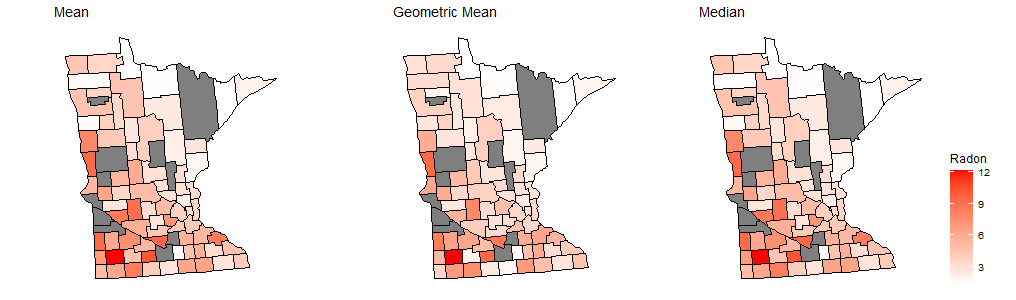

The maps of characteristics of radon concentration in counties in picoCurie per liter. The gray colour means that the value is NA (Not Available)

In all considered examples, the prediction for the county no. 26 (`county == 26`) is conducted and it is assumed that the observations in this county from the first floor (`basement == 1`) are not available (see Figure @ref(fig:boxplot)).

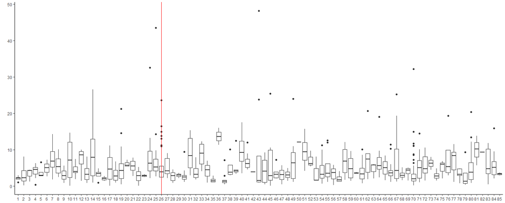

The distributions of radon concentration in picoCurie per liter in counties. The red line indicates county no. 26

The `radon` dataset is widely discussed in the literature. In the paper (Nero et al. 1994), the Authors used an ordinary regression model to predict county geometric means of radon concentration using surficial soil radium data from the National Uranium Resource Evaluation. In turn, the paper (Phillip N. Price, Nero, and Gelman 1996) focuses on the prediction of the geometric mean of radon for each county, but using a Bayesian approach. For the `radon` data we use the following model
$$\label{radon.model}
log(Y_{ic}) = \beta_1 x_{1ic} + (\beta_2 + v_{1c}) x_{2ic} + \beta_0
+ v_{2c} + e_{ic}, (\#eq:radon-model)$$
where $i=1,2,\dots,N$, $c=1,2,\dots, C$, $N = 919$ observations, $C = 85$ counties, $\beta_1$, $\beta_2$ and $\beta_0$ are unknown fixed effects, $v_{1c}$ and $v_{2c}$ are random effects, $e_{ic}$ are random components, $v_{1c}$, and $e_{ic}$ are mutually independent, $v_{2c}$ and $e_{ic}$ are mutually independent too, $Cor(v_{1c}, v_{2c}) = \rho$, $v_{1c} \sim (0, \sigma^2_{v_1})$, $v_{2c} \sim (0, \sigma^2_{v_2})$ and $e_{ic} \sim (0, \sigma^2_e)$. As can easily be seen, the considered model is the random coefficient model with two correlated `county`-specific random effects. Its syntax written using the package [**lme4**](https://CRAN.R-project.org/package=lme4) notation is as follows:

```r
radon.model <-  lmer(log.radon ~ basement + uranium + (basement | county), data = radon)
```

This and similar LMMs are considered, analyzed, and used for the considered dataset in many publications, with a good overview presented in (Gelman and Hill 2006). In (Gelman and Pardoe 2006), based on their preceding research (Phillip N. Price, Nero, and Gelman 1996), (Lin et al. 1999), (Phillip N. Price and Gelman 2005), a very similar model but with additional multivariate normality assumptions is studied, verified and chosen as fitting well to the data within a Bayesian framework. The same model as in (Gelman and Pardoe 2006) with its special cases is considered in (Cantoni, Jacot, and Ghisletta 2021) but within the frequentist approach. Based on 25 measures of explained variation and model selection, the Authors conclude that the same model as considered in our paper (with additional normality assumption, however, which is not used in all cases considered in that paper), "seems the best" (Cantoni, Jacot, and Ghisletta 2021, 10) for the `radon` data. Further tests of the model are presented by (Loy 2013), (Loy and Hofmann 2015) and (Loy, Hofmann, and Cook 2017) (see also (Cook, Swayne, and Buja 2007) for the introduction of the methodology) showing among others: the normality and homescedasticity of random components, the normality of the distribution of the random slope but – what is important for our further considerations – the lack of the normality of the random intercept. Since the problem of choosing and verifying a model for the considered dataset is widely discussed in the literature, we will focus on the issues that are new in this case, namely the problem of prediction and estimation of the prediction accuracy as well as the Monte Carlo analysis of predictors’ properties.